# Bootstrapped Models

Alexander Tuzhikov

September 29, 2016

```r
#compile gbra to ensure it's up to date
library(devtools)
install_github("axrt/gbra")#actually at this moment there is a lot of functionality that needs to be updated
library(gbra)
source("R/helper.R")
sixtyseven.genomes<-"67.genomes"
model.df.file<- "model.df.txt"
bh.data.raw.file<- "bh.data.raw.rda"
bh.data.normal.file<- "bh.data.normal.rda"
library(doMC)
library(doParallel)
library(foreach)
library(ggplot2)
library(data.table)
Rsq.cutoff<- 0.73
logfile<- "log.txt"
library(plyr)
library(dplyr)
install_github("vqv/ggbiplot")
library(boot)
library(pander)
library(seplyr)
```

We create a legend, that will only contain the genomes that we want to include (the others are not good enough for this or that reason)

```r
legend<- read.table(file=sixtyseven.genomes.dir("legend.txt"), sep="\t", header=TRUE, stringsAsFactors = FALSE) %>%
  dplyr::filter(id_genomes!=23) %>%
  dplyr::filter(id_genomes!=40) %>%
  dplyr::filter(id_genomes!=47) %>%
  dplyr::filter(id_genomes!=57) %>%
  dplyr::filter(id_genomes!=63) %>%
  dplyr::filter(id_genomes!=64) %>%
  dplyr::select(name, id_genomes) %>%
  dplyr::arrange(id_genomes)
```

We load the bidirectional hits form the previous iterations of analaysis.

```r
load(sixtyseven.genomes.dir(bh.data.raw.file))
```

Convert the bh data to a normalized form, genome ids and minimal hits restricted (4 in this case)

```r
bh.data%>%
    as.data.frame %>%
    restrict.minimal.hits(minhit = 4) %>%
    normalize.scores %>%
    attach.genomeid.header %>%
    sign.bh.table -> bh.data.norm
rm(bh.data) #saves ram quite a bit
bh.data.norm %>% head %>% pander(caption="Best Hit DataFrame")
```

Best Hit DataFrame (continued below)

|  | X1 | X10 | X11 | X12 | X13 | X14 | X15 | X16 |
| --- | --- | --- | --- | --- | --- | --- | --- | --- |
| **1X8** | 1 | 0.09708 | 0 | 0.117 | 0.1585 | 0 | 0 | 0.1388 |
| **1X10** | 1 | 0 | 0 | 0.1247 | 0 | 0 | 0 | 0 |
| **1X17** | 1 | 0.2406 | 0 | 0.2153 | 0.2231 | 0 | 0 | 0 |
| **1X37** | 1 | 0.4631 | 0 | 0.4824 | 0.4378 | 0.4515 | 0 | 0 |
| **1X39** | 1 | 0 | 0 | 0 | 0.2079 | 0 | 0 | 0 |
| **1X54** | 1 | 0.5643 | 0.5771 | 0.5455 | 0.5721 | 0.5354 | 0.4596 | 0.5231 |

Table continues below

|  | X17 | X18 | X19 | X2 | X20 | X21 | X22 |
| --- | --- | --- | --- | --- | --- | --- | --- |
| **1X8** | 0 | 0.04753 | 0 | 0.08968 | 0.063 | 0 | 0 |
| **1X10** | 0 | 0.1484 | 0 | 0.155 | 0 | 0 | 0 |
| **1X17** | 0.1214 | 0 | 0 | 0 | 0.1624 | 0 | 0 |
| **1X37** | 0.1299 | 0 | 0 | 0 | 0.1531 | 0.4141 | 0.1498 |
| **1X39** | 0 | 0 | 0 | 0 | 0 | 0.2116 | 0 |
| **1X54** | 0.4303 | 0.4503 | 0 | 0.5291 | 0.4121 | 0.436 | 0.578 |

Table continues below

|  | X24 | X25 | X26 | X27 | X28 | X3 | X30 |
| --- | --- | --- | --- | --- | --- | --- | --- |
| **1X8** | 0.05268 | 0.05515 | 0 | 0.1047 | 0.09976 | 0.06434 | 0 |
| **1X10** | 0.1366 | 0 | 0 | 0 | 0 | 0 | 0 |
| **1X17** | 0 | 0 | 0 | 0.1594 | 0.2742 | 0 | 0 |
| **1X37** | 0 | 0 | 0 | 0.522 | 0.1151 | 0 | 0 |
| **1X39** | 0 | 0 | 0 | 0 | 0 | 0 | 0 |
| **1X54** | 0 | 0.4769 | 0.5947 | 0.5745 | 0.6643 | 0.6222 | 0.4321 |

Table continues below

|  | X31 | X32 | X33 | X34 | X35 | X36 | X37 |
| --- | --- | --- | --- | --- | --- | --- | --- |
| **1X8** | 0.1269 | 0.1069 | 0.1004 | 0 | 0 | 0.06995 | 0 |
| **1X10** | 0 | 0 | 0.1247 | 0 | 0 | 0 | 0 |
| **1X17** | 0.1205 | 0.2476 | 0 | 0 | 0 | 0 | 0 |
| **1X37** | 0.3012 | 0.5424 | 0 | 0 | 0 | 0 | 0 |
| **1X39** | 0 | 0 | 0 | 0 | 0 | 0 | 0 |
| **1X54** | 0.533 | 0.4551 | 0.5536 | 0.4488 | 0.2733 | 0.5058 | 0.3969 |

Table continues below

|  | X38 | X39 | X4 | X41 | X42 | X43 | X44 |
| --- | --- | --- | --- | --- | --- | --- | --- |
| **1X8** | 0.2901 | 0 | 0.05672 | 0.08945 | 0.05044 | 0.07353 | 0 |
| **1X10** | 0 | 0 | 0 | 0.1669 | 0 | 0.1276 | 0 |
| **1X17** | 0 | 0 | 0 | 0 | 0.1672 | 0.231 | 0 |
| **1X37** | 0 | 0 | 0 | 0 | 0.2285 | 0.3469 | 0.5165 |
| **1X39** | 0.2033 | 0 | 0 | 0 | 0 | 0 | 0 |
| **1X54** | 0.6228 | 0.567 | 0.6329 | 0.4193 | 0.442 | 0.4688 | 0.459 |

Table continues below

|  | X45 | X46 | X48 | X49 | X5 | X50 | X51 |
| --- | --- | --- | --- | --- | --- | --- | --- |
| **1X8** | 0.1007 | 0 | 0.07017 | 0.08788 | 0.1004 | 0.1592 | 0 |
| **1X10** | 0 | 0.1657 | 0.2244 | 0.1651 | 0 | 0.1306 | 0.1318 |
| **1X17** | 0.2956 | 0 | 0 | 0 | 0.2498 | 0 | 0 |
| **1X37** | 0 | 0 | 0.5011 | 0.5055 | 0 | 0.1239 | 0 |
| **1X39** | 0 | 0 | 0 | 0 | 0 | 0 | 0 |
| **1X54** | 0.5076 | 0.4264 | 0.5679 | 0.5386 | 0.6258 | 0.4515 | 0 |

Table continues below

|  | X52 | X53 | X54 | X55 | X56 | X58 | X59 | X6 |
| --- | --- | --- | --- | --- | --- | --- | --- | --- |
| **1X8** | 0.07937 | 0 | 0 | 0 | 0 | 0 | 0 | 0 |
| **1X10** | 0.1948 | 0 | 0 | 0 | 0 | 0 | 0 | 0 |
| **1X17** | 0 | 0 | 0 | 0 | 0.1157 | 0 | 0 | 0 |
| **1X37** | 0 | 0.1944 | 0.4708 | 0 | 0 | 0 | 0 | 0.4477 |
| **1X39** | 0.4787 | 0 | 0.1987 | 0 | 0 | 0 | 0 | 0 |
| **1X54** | 0.5189 | 0.3954 | 0.4933 | 0.4509 | 0.4414 | 0 | 0.4124 | 0 |

Table continues below

|  | X60 | X62 | X65 | X66 | X67 | X68 | X69 |
| --- | --- | --- | --- | --- | --- | --- | --- |
| **1X8** | 0 | 0.08429 | 0 | 0 | 0.2874 | 0 | 0 |
| **1X10** | 0 | 0 | 0 | 0.1336 | 0 | 0 | 0 |
| **1X17** | 0 | 0 | 0.1581 | 0.1554 | 0.1716 | 0 | 0 |
| **1X37** | 0 | 0 | 0.5187 | 0.5154 | 0.1239 | 0.4124 | 0 |
| **1X39** | 0 | 0 | 0 | 0 | 0.2375 | 0 | 0 |
| **1X54** | 0.3154 | 0.6368 | 0.4619 | 0.5428 | 0.5837 | 0.4375 | 0.444 |

|  | X7 | X8 | X9 |
| --- | --- | --- | --- |
| **1X8** | 0 | 0.1455 | 0 |
| **1X10** | 0.1645 | 0.1259 | 0 |
| **1X17** | 0 | 0.1118 | 0 |
| **1X37** | 0 | 0.1399 | 0.2197 |
| **1X39** | 0 | 0 | 0 |
| **1X54** | 0.4187 | 0.6117 | 0.4187 |

Now, create the model driver data frame, which will contain model pairs (see below).

```r
model.driver<- create.model.driver(legend)
model.driver %>% head %>% pander(caption="Model Driver DataFrame")
```

Model Driver DataFrame

| X1 | X2 | file |
| --- | --- | --- |
| 1 | 2 | 1_2_model.rda |
| 1 | 3 | 1_3_model.rda |
| 1 | 4 | 1_4_model.rda |
| 1 | 5 | 1_5_model.rda |
| 1 | 6 | 1_6_model.rda |
| 1 | 7 | 1_7_model.rda |

Create a log file for the multitheaded processing below, remove the file if it exists.

```r
model.training.log.file<- "model.training.log.txt" %>% sixtyseven.genomes.quadruple.model
if(model.training.log.file %>% file.exists){
        file.remove(model.training.log.file)
}
```

`logreg.model.bootstrap` is going to be a funciton that will return betta coefficients for models that we are going to get in the bootstrap process.

```r
logreg.model.bootstrap<-function(data, indices, formula){
  working.data<-data[indices,]
  glm.fit<-glm(formula = formula, data=working.data, family="binomial")
  return(glm.fit$coefficients)
}
```

Train models, skip if the model has already been trained.

```r
models<- foreach(i=1:nrow(model.driver)) %do%{

  org.pair<- c(model.driver$X1[i], model.driver$X2[i])
  out.file.stepped<- sixtyseven.genomes.quadruple.model.bootstrapped(paste0(org.pair[1], "_", org.pair[2],".stepped.rds"))
  out.file.bootstrapped<- sixtyseven.genomes.quadruple.model.bootstrapped(paste0(org.pair[1], "_", org.pair[2],".bootstrapped.rds"))
  if(file.exists(out.file.bootstrapped)){
    return(out.file.bootstrapped)
  }
  message(paste("Doing", org.pair[1], "::", org.pair[2]))

  coocked.data<- bh.data.norm %>% select.genome.data(org.pair) %>%
      filter.genome.data(org.pair) %>%
      append.cluster %>% data.frame

  f<- get.glm.formula(coocked.data)
  glm.fit<- glm(formula = f, data=coocked.data, family="binomial")
  glm.fit<- step(glm.fit)
  saveRDS(object = glm.fit,
          file = out.file.stepped,
          compress = "gzip")
  model<-boot(glm.fit$model, logreg.model.bootstrap, R=1000, formula=glm.fit$formula, parallel = "multicore", ncpus = 6)
  model.coeff<- apply(model$t, 2, median)
  names(model.coeff)<- names(model$t0)
  glm.fit$coefficients<- model.coeff

  saveRDS(object = glm.fit,
          file = out.file.bootstrapped,
          compress = "gzip")
  return(out.file.bootstrapped)
}
```

We append paths to the model files to the model driver and save the driver to a file to use later.

```r
registerDoMC(cores=6)
model.driver.file<- "model.driver.bootstrapped.txt" %>% sixtyseven.genomes.quadruple.model
if(!model.driver.file %>% file.exists){

    model.driver$rsquared<- foreach(i=1:nrow(model.driver), .combine="c") %dopar%{
    org.pair<- c(model.driver$X1[i], model.driver$X2[i])
    out.file<- sixtyseven.genomes.quadruple.model.bootstrapped(paste0(org.pair[1], "_", org.pair[2],".bootstrapped.rds"))
   model<- readRDS(file=out.file)

   return(get.rsq(model))
    }
    write.table(model.driver, file=model.driver.file, sep="\t", quote = FALSE)
}else{
    model.driver<- read.table(model.driver.file, sep="\t", header=TRUE, stringsAsFactors = FALSE)
}
model.driver %>% head %>% pander(caption="Updated Model Driver DataFrame")
```

Updated Model Driver DataFrame

| X1 | X2 | file | rsquared |
| --- | --- | --- | --- |
| 1 | 2 | 1_2_model.rda | 0.05169 |
| 1 | 3 | 1_3_model.rda | 0.8749 |
| 1 | 4 | 1_4_model.rda | 0.8742 |
| 1 | 5 | 1_5_model.rda | 0.08929 |
| 1 | 6 | 1_6_model.rda | 0.9173 |
| 1 | 7 | 1_7_model.rda | 0.8528 |

Now we will go over all models and collect the R-squared values. That will be for *D.simulans*, and we will plot a line at R-squared = 0.73 because this value roughly corresponds to 95% specificity.

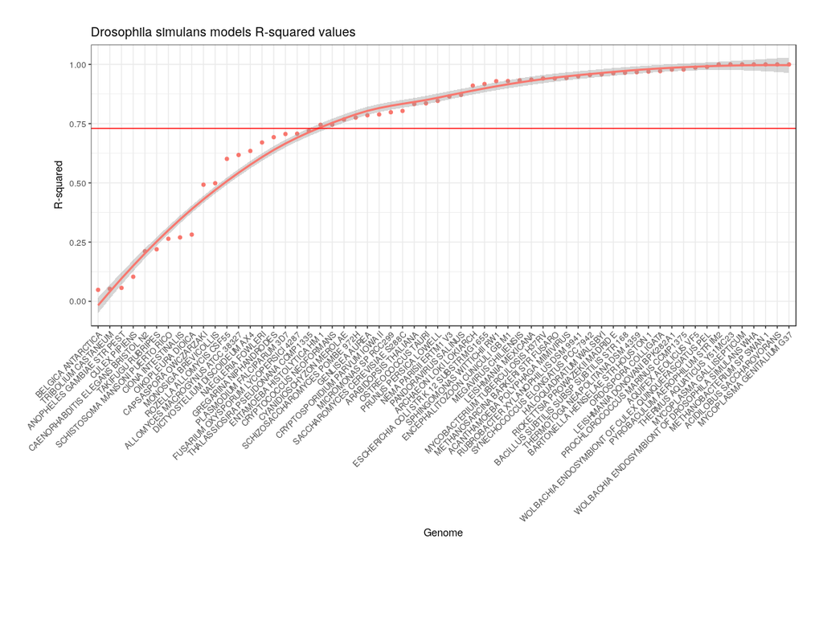

```r
rsq.plot<- model.driver %>%
  rename(query.genome=X1, target.genome=X2) %>%
  filter(query.genome==6|target.genome==6) %>%
  mutate(target.genome=sapply(1:length(.$target.genome), function(x){
  if(.$target.genome[x]==6){
    return(.$query.genome[x])
  }else{
    return(.$target.genome[x])
  }
})) %>%
  select(rsquared, target.genome) %>%
  merge(x=., y=legend, by.x="target.genome", by.y="id_genomes") %>%
  mutate(name=str_trim(toupper(str_replace_all(string=.$name, pattern = "\\.fasta|_|complete_genome|chromosome", replacement=" ")))) %>%
  arrange(rsquared) %>%
  mutate(name=factor(.$name, levels=.$name)) %>%
  melt(id.vars="name") %>%
  filter(variable %in% c("rsquared")) %>%
  ggplot(data=., mapping=aes(x=name, y=value, group=variable, color=variable)) + geom_point() +
  geom_smooth() +
  theme_bw() + theme(axis.text.x=element_text(angle = 45, hjust = 1), legend.position="none", plot.margin = unit(c(1, 1, 3, 2), "cm"), axis.title.x=element_text(vjust=1)) +
  geom_hline(yintercept = 0.73, color="red") +
  xlab("Genome") + ylab("R-squared") + labs(title = "Drosophila simulans models R-squared values")

plot(rsq.plot)
```

```r
pdf(file = "rsq.drosoph.bootstrapped.pdf"%>% sixtyseven.genomes.quadruple.model, width = 15, height=8)
plot(rsq.plot)
dev.off()
```

I have been stealing some code from previous analysis, so here I will have some hacks to have it compatible with the current iteration. The huuuuge chunck of code below will create a so called master-core-table for our bootstrapped models. It will show for each orf on the analysis for each organism if we could crearly separate the given orf, and, if we could, whether it went to core, or did not and thus fell into the cluster of the opposing genome. We chose wide margin of (0.025, 0.975) of probability which keeps the orf as “not separated” for any orf that had cluster assignment probability fall into this margin. In human language (mostly, if I put myself together to write it better), if we have an orf and a model predicts it’s porbability to go into cluster A (from A and B cluster pair) as say 0.6 - it is not good enough and we say, that we do not have enough evidence ot have this orf assigned to a particular cluster. But for a case of probability 0.98, of an orf to be from a certain cluster - we say that yes, this is good enough and this orf is comeing from its origin cluster (core) or from an opposing cluster (outsider).

```r
bh.data<- bh.data.norm
factor.core<-c("core","outsider","nosep") #generate three factors to mark states
if(!"master.table.core.bootstrapped.0025.txt" %>% sixtyseven.genomes.quadruple.model %>% file.exists){
  #generate a matrix big enough to hold the data (essentially the same size as the bh.data), initially filled in with "outsider"
  master.table.core<-as.data.frame(
          matrix(
                  nrow=nrow(bh.data),
                  ncol=nrow(legend),
                  factor.core[3]),
          stringsAsFactors = FALSE)
  #copy the row names from bh.data
  row.names(master.table.core)<-row.names(bh.data)
  #copy colnames from the legend
  colnames(master.table.core)<-legend$id_genomes
  #now, for each row in the initial bh.table go over the models one by one, load them into ram and see where the row gene is placed
  #relative to each genome
  registerDoMC(cores=6)
  writeLines(c(""), "log.txt")
  master.table.core.list<-foreach(i=1:(nrow(legend)-1))%do%{
    #j must be i+1 because the diagonas are always "nonsep" as you can't really separate the organism with itself
    foreach(j=(i+1):nrow(legend))%dopar%{
        sink("log.txt", append=TRUE)
        #load the corresponding model list
        model.file<- paste(
                paste(
                        legend$id_genomes[i],
                        legend$id_genomes[j],
                        sep="_"),
                ".bootstrapped.rds",
                sep = "") %>% sixtyseven.genomes.quadruple.model.bootstrapped
        l.m.g<- readRDS(file=model.file)
        #see if all models are present in the list (which indicates that the separation can be done definitively in all attempts with a given rsquared)
        if(get.rsq(l.m.g)>=0.73){
                #select corresponding genomes
                data.table<-select.genome.data(bh.data, c(legend$id_genomes[i],legend$id_genomes[j])) %>% filter.genome.data(c(legend$id_genomes[i],legend$id_genomes[j]))
                #attempt to predict the probabilities for each pair with a precalculated logistic regression
                data.table$cluster<-grepl(pattern = paste("\\b",legend$id_genomes[i],"X",sep = "",collapse = ""),x = rownames(data.table),perl = TRUE)
                glm.probs<- predict(l.m.g, data.table, type = "response")
                glm.probs.groups<- sapply(glm.probs,function(l){
                                if(l<0.025){
                                        return(TRUE)
                                }
                                else if(l>0.975){
                                        return(FALSE)
                                }else{
                                      return(NA)
                                }
                                })

                sep.factor.v<- sapply(1:length(data.table$cluster), function(i){
                        if(is.na(glm.probs.groups[i])){
                                return(factor.core[3])
                        }
                        if(data.table$cluster[i]==glm.probs.groups[i]){
                                return(factor.core[2])
                        }else{
                                return(factor.core[1])
                        }
                })
                sep.factor.v<- ifelse(test=data.table$cluster==glm.probs.groups, yes=factor.core[2], no=factor.core[1])

                output.table<- cbind(name=rownames(data.table), cluster=data.table$cluster, match=sep.factor.v==factor.core[1]) %>% data.frame
                write.table(x=output.table, file=paste(legend$id_genomes[i], legend$id_genomes[j], sep="_") %>%
                                    paste0(".txt.bootstrapped.match") %>% sixtyseven.genomes.quadruple.model.match(),
                            sep="\t", quote = FALSE, row.names = FALSE)
          #assign common name identificators like "X1,2..." in accordance with the legend
          sep.factor.v.i<-sep.factor.v[grepl(pattern = paste("\\b",legend$id_genomes[i],"X",sep = "",collapse = ""),x = names(sep.factor.v),perl = TRUE)]
          sep.factor.v.j<-sep.factor.v[grepl(pattern = paste("\\b",legend$id_genomes[j],"X",sep = "",collapse = ""),x = names(sep.factor.v),perl = TRUE)]
          core.col.j<-which(legend$id_genomes==legend$id_genomes[j])
          core.col.i<-which(legend$id_genomes==legend$id_genomes[i])
          #mark i and j cells (because the matrix here is not triangle and needs symmetry)
          return(list(sep.factor.v.i, sep.factor.v.j, core.col.i, core.col.j))
        }else{
                return(list(i, j))
        }
    }
  }
  for(i in 1:length(master.table.core.list)){
          for(j in 1:length(master.table.core.list[[i]])){
                  if(length(master.table.core.list[[i]][[j]])==4){
                          print(paste("Doing:", i, j, sep=" "))
                          sep.factor.v.i<- master.table.core.list[[i]][[j]][[1]]
                          sep.factor.v.j<- master.table.core.list[[i]][[j]][[2]]
                          core.col.i<- master.table.core.list[[i]][[j]][[3]]
                          core.col.j<- master.table.core.list[[i]][[j]][[4]]
                          master.table.core[names(sep.factor.v.i),core.col.j]<-sep.factor.v.i
                          master.table.core[names(sep.factor.v.j),core.col.i]<-sep.factor.v.j
                  }
          }
  }

  #finally save out the resulting table
  write.table(x=master.table.core, file="master.table.core.bootstrapped.0025.txt" %>% sixtyseven.genomes.quadruple.model, sep="\t", quote = FALSE)
}
```

```r
#read the data
master.table.core<-read.table(file="master.table.core.bootstrapped.0025.txt" %>% sixtyseven.genomes.quadruple.model)
master.table.core[is.na(master.table.core)]<- factor.core[3]
master.table.core %>% head %>% pander(caption="Master Table Core DataFrame")
```

Master Table Core DataFrame (continued below)

|  | X1 | X2 | X3 | X4 | X5 | X6 | X7 | X8 |
| --- | --- | --- | --- | --- | --- | --- | --- | --- |
| **1X8** | nosep | nosep | core | core | nosep | core | nosep | nosep |
| **1X10** | nosep | nosep | core | core | nosep | core | nosep | nosep |
| **1X17** | nosep | nosep | core | core | nosep | core | core | nosep |
| **1X37** | nosep | nosep | core | core | nosep | nosep | core | nosep |
| **1X39** | nosep | nosep | core | core | nosep | core | nosep | nosep |
| **1X54** | nosep | nosep | nosep | nosep | nosep | core | nosep | nosep |

Table continues below

|  | X9 | X10 | X11 | X12 | X13 | X14 | X15 | X16 |
| --- | --- | --- | --- | --- | --- | --- | --- | --- |
| **1X8** | nosep | nosep | nosep | nosep | nosep | core | core | nosep |
| **1X10** | nosep | nosep | nosep | nosep | nosep | nosep | core | nosep |
| **1X17** | nosep | nosep | nosep | nosep | nosep | core | core | nosep |
| **1X37** | outsider | nosep | nosep | nosep | nosep | outsider | nosep | nosep |
| **1X39** | nosep | nosep | nosep | nosep | nosep | nosep | core | nosep |
| **1X54** | nosep | nosep | nosep | nosep | nosep | core | core | nosep |

Table continues below

|  | X17 | X18 | X19 | X20 | X21 | X22 | X24 |
| --- | --- | --- | --- | --- | --- | --- | --- |
| **1X8** | core | nosep | nosep | nosep | core | core | nosep |
| **1X10** | core | nosep | nosep | nosep | core | nosep | nosep |
| **1X17** | core | nosep | nosep | nosep | core | nosep | nosep |
| **1X37** | outsider | nosep | nosep | outsider | outsider | outsider | nosep |
| **1X39** | nosep | nosep | nosep | nosep | nosep | nosep | nosep |
| **1X54** | core | nosep | nosep | core | nosep | nosep | nosep |

Table continues below

|  | X25 | X26 | X27 | X28 | X30 | X31 | X32 | X33 |
| --- | --- | --- | --- | --- | --- | --- | --- | --- |
| **1X8** | nosep | nosep | nosep | nosep | core | nosep | nosep | nosep |
| **1X10** | nosep | nosep | nosep | nosep | nosep | nosep | nosep | nosep |
| **1X17** | nosep | nosep | nosep | nosep | core | nosep | nosep | nosep |
| **1X37** | nosep | nosep | nosep | nosep | outsider | nosep | nosep | nosep |
| **1X39** | nosep | nosep | nosep | nosep | nosep | nosep | nosep | nosep |
| **1X54** | nosep | nosep | nosep | nosep | nosep | nosep | nosep | nosep |

Table continues below

|  | X34 | X35 | X36 | X37 | X38 | X39 | X41 | X42 |
| --- | --- | --- | --- | --- | --- | --- | --- | --- |
| **1X8** | nosep | nosep | nosep | core | nosep | nosep | nosep | nosep |
| **1X10** | nosep | nosep | nosep | nosep | nosep | nosep | nosep | nosep |
| **1X17** | nosep | nosep | nosep | core | nosep | nosep | nosep | nosep |
| **1X37** | nosep | nosep | nosep | nosep | nosep | nosep | nosep | nosep |
| **1X39** | nosep | nosep | nosep | nosep | nosep | nosep | nosep | nosep |
| **1X54** | nosep | nosep | nosep | core | nosep | nosep | nosep | nosep |

Table continues below

|  | X43 | X44 | X45 | X46 | X48 | X49 | X50 | X51 |
| --- | --- | --- | --- | --- | --- | --- | --- | --- |
| **1X8** | nosep | core | nosep | nosep | nosep | nosep | nosep | nosep |
| **1X10** | nosep | nosep | nosep | nosep | nosep | nosep | nosep | nosep |
| **1X17** | nosep | core | nosep | nosep | nosep | nosep | nosep | nosep |
| **1X37** | nosep | outsider | nosep | nosep | nosep | nosep | nosep | nosep |
| **1X39** | nosep | nosep | nosep | nosep | nosep | nosep | nosep | nosep |
| **1X54** | nosep | nosep | nosep | core | nosep | nosep | nosep | nosep |

Table continues below

|  | X52 | X53 | X54 | X55 | X56 | X58 | X59 | X60 |
| --- | --- | --- | --- | --- | --- | --- | --- | --- |
| **1X8** | nosep | nosep | nosep | nosep | nosep | nosep | core | core |
| **1X10** | nosep | nosep | nosep | nosep | nosep | nosep | core | core |
| **1X17** | nosep | nosep | nosep | nosep | nosep | nosep | core | core |
| **1X37** | nosep | nosep | nosep | nosep | nosep | nosep | core | core |
| **1X39** | nosep | nosep | nosep | nosep | nosep | nosep | nosep | core |
| **1X54** | nosep | nosep | nosep | nosep | nosep | nosep | core | core |

|  | X62 | X65 | X66 | X67 | X68 | X69 |
| --- | --- | --- | --- | --- | --- | --- |
| **1X8** | nosep | core | core | nosep | core | core |
| **1X10** | nosep | core | core | nosep | core | core |
| **1X17** | nosep | core | core | nosep | core | core |
| **1X37** | nosep | nosep | nosep | nosep | outsider | core |
| **1X39** | nosep | core | core | nosep | nosep | core |
| **1X54** | nosep | core | core | nosep | core | core |

```r
#create a parallel cluster with the cluster log output
if(logfile %>% file.exists()){
        file.remove(logfile)
}
```

```
## [1] TRUE
```

```r
cluster <<- makeCluster(6,outfile = logfile)
registerDoParallel(cluster)
#create a diriving summary of genes
master.table.core.per.gene.summary<-as.data.frame(
        t(
                parApply(cl=cluster, X = master.table.core, MARGIN = 1, FUN = function(i){
                        sum.core<-length(i[i=="core"])
                        sum.outsider<-length(i[i=="outsider"])
                        sum.nosep<-length(i[i=="nosep"])
                        return(c(core=sum.core, outsider=sum.outsider, nonsep=sum.nosep))
})))
#do not forget to close the cluster
stopCluster(cluster)
```

The so called “frequent outsides” below are essentially the genes that were marked by the models as “outsiders” many times, thus suggesting that the origin of these orfs is different from their host genome.

```r
#append the names because the following filter will erase the rownames
master.table.core.per.gene.summary$gene.name<-row.names(master.table.core.per.gene.summary)
#separate the "always core table"
master.table.core.always.core<- master.table.core.per.gene.summary %>% filter(outsider==0)
head(master.table.core.always.core) %>% pander(caption="Mater Table Core")
```

Mater Table Core

| core | outsider | nonsep | gene.name |
| --- | --- | --- | --- |
| 17 | 0 | 44 | 1X8 |
| 12 | 0 | 49 | 1X10 |
| 17 | 0 | 44 | 1X17 |
| 8 | 0 | 53 | 1X39 |
| 13 | 0 | 48 | 1X54 |
| 22 | 0 | 39 | 1X59 |

```r
#separate the "outsider once"
master.table.core.outsider.once<- master.table.core.per.gene.summary %>% filter(outsider==1)
head(master.table.core.outsider.once) %>% pander(caption="One Time Outsiders")
```

One Time Outsiders

| core | outsider | nonsep | gene.name |
| --- | --- | --- | --- |
| 4 | 1 | 56 | 1X638 |
| 8 | 1 | 52 | 1X2086 |
| 3 | 1 | 57 | 1X2917 |
| 9 | 1 | 51 | 1X7396 |
| 4 | 1 | 56 | 1X9503 |
| 7 | 1 | 53 | 1X10411 |

```r
#separate the frequent outsider
master.table.core.outsider.frequently<- master.table.core.per.gene.summary %>% filter(outsider>1)
head(master.table.core.outsider.frequently) %>% pander(caption="Frequent Outsiders")
```

Frequent Outsiders

| core | outsider | nonsep | gene.name |
| --- | --- | --- | --- |
| 6 | 9 | 46 | 1X37 |
| 3 | 7 | 51 | 1X1773 |
| 4 | 6 | 51 | 1X2780 |
| 3 | 12 | 46 | 1X2789 |
| 6 | 3 | 52 | 1X3324 |
| 6 | 7 | 48 | 1X3444 |

```r
#write out the data
write.table(master.table.core.always.core,
            file="master.table.core.always.core.bootstrapped.txt" %>% sixtyseven.genomes.quadruple.model,
            sep="\t", col.names=TRUE, quote = FALSE)
write.table(master.table.core.outsider.once,
            file="master.table.core.outsider.once.bootstrapped.txt" %>% sixtyseven.genomes.quadruple.model,
            sep="\t", col.names=TRUE, quote = FALSE)
write.table(master.table.core.outsider.frequently,
            file="master.table.core.outsider.frequently.bootstrapped.txt" %>% sixtyseven.genomes.quadruple.model,
            sep="\t", col.names=TRUE, quote = FALSE)
#
```

The hectic superlogng function below is a minor modification of the one that is present in the `gbra` helper package and is redefined here because the previous one was very slow, and this one is faster (and will replace the original one in `gbra`).

```r
calculate.clustering.table<- function(bh.data, rsquared.cutoff, rsquared.table, legend, processors=4, data.folder=data.folder){
        registerDoMC(processors)
        #for each match table find the genes that are in the core and those, that are outsiders
        core.outsider.list<-foreach(x=1:nrow(rsquared.table), .errorhandling = "stop", .verbose = FALSE)%dopar%{
                #extract i and j from the filename
                ij<- strsplit(x = rsquared.table$match.file.name[x], split = ".", fixed=TRUE)
                ij<- strsplit(x = ij[[1]][1], split = "_", fixed=TRUE)
                i<- as.numeric(ij[[1]][1])
                j<- as.numeric(ij[[1]][2])
                if(file.exists(data.folder(rsquared.table$match.file.name[x]))){
                         match.table<- fread(input = data.folder(rsquared.table$match.file.name[x]), sep = "\t", data.table = FALSE, stringsAsFactors = FALSE)
                }else{
                         match.table<- select.genome.data(bh.data, c(i,j)) %>% filter.genome.data(c(i,j))
                         match.table<- match.table %>% mutate(name=rownames(match.table))
                }

                #split by genome ids
                i.columns<- match.table %>% filter(grepl(pattern = paste0("\\b",i,"X"),x = name,perl = TRUE))
                j.columns<- match.table %>% filter(grepl(pattern = paste0("\\b",j,"X"),x = name,perl = TRUE))
                #if the rsquared is too low, then just return a nonsep-filled columns
                if(is.na(rsquared.table$rsquared[x])||rsquared.table$rsquared[x]<rsquared.cutoff){
                        i.col=rep("nosep",nrow(i.columns))
                        names(i.col)<- i.columns$name
                        j.col=rep("nosep",nrow(j.columns))
                        names(j.col)<- j.columns$name
                        return(list(i.col=i.col, j.col=j.col, i=i, j=j))
                }else{
                        i.col=sapply(i.columns$match, function(k){
                                if(is.na(k)){
                                        return("nosep")
                                }
                                if(k){
                                        return("core")
                                }else{
                                        return("outsider")
                                }
                        })
                        names(i.col)<- i.columns$name
                        j.col=sapply(j.columns$match, function(k){
                                if(is.na(k)){
                                        return("nosep")
                                }
                                if(k){
                                        return("core")
                                }else{
                                        return("outsider")
                                }
                        })
                        names(j.col)<- j.columns$name
                        return(list(i.col=i.col, j.col=j.col, i=i, j=j))
                }
        }
        core.outsider.list<-lapply(legend$id_genomes,function(i){
                sub.list<- lapply(core.outsider.list,function(j){
                        if(j$i==i){
                                return(j)
                        }
                })
                return(sub.list[!sapply(sub.list,is.null)])
        })
        core.outsider.list<- core.outsider.list[-length(core.outsider.list)]
        core.outsider.list<- lapply(core.outsider.list, function(x){
                diagonal.element<- list(i.col = rep("nosep",length(x[[1]]$i.col)),j.col = rep("nosep",length(x[[1]]$i.col)), i=x[[1]]$i, j=x[[1]]$i)
                names(diagonal.element$i.col)<- names(x[[1]]$i.col)
                names(diagonal.element$j.col)<- names(x[[1]]$i.col)
                return(append(x = x,values = list(diagonal.element),0))
        })
        last.genome<- select.genomes(df = bh.data, g.ids = legend$id_genomes[nrow(legend)])
        last.genome.list<-list(list(i.col=rep("nosep", nrow(last.genome)),
                                    j.col=rep("nosep",nrow(last.genome)),
                                    i=legend$id_genomes[nrow(legend)],
                                    j=legend$id_genomes[nrow(legend)]))
        names(last.genome.list[[1]]$i.col)<- rownames(last.genome)
        names(last.genome.list[[1]]$j.col)<- rownames(last.genome)
        core.outsider.list[[length(core.outsider.list)+1]]<- last.genome.list
        return(core.outsider.list)
}
```

The rest of the funcitons can be borrowed form previous analysis.

```r
#first prepare the functions
source("R/extract.cores.R")
source("R/convert.core.list.matrix.R")
```

The enormous and unreadable pipe below will create a “clustering list” (that is a list, which is essentially an upper triangular matrix of orfs vs genomes).

```r
#load the core-outsider data
model.df<- cbind.data.frame(query.genome=model.driver$X1, target.genome=model.driver$X2, rsquared=model.driver$rsquared)
model.df$match.file.name<- sapply(1:nrow(model.df), function(i){
        return(
                paste0(model.df[i,1], '_', model.df[i,2], '.txt.bootstrapped.match')
        )
})
model.df[is.na(model.df[,3]),3]<-0

clustering.list<- calculate.clustering.table(
  bh.data = bh.data, rsquared.cutoff = 0.73, rsquared.table = model.df, legend = legend, processors = 8,
  data.folder=sixtyseven.genomes.quadruple.model.match)

core.distribution.data<- convert.core.list.matrix(clustering.list = clustering.list, legend = legend)
```

```
## [1] "list"
```

A plot below will demonstate the amount of genes from outsider and core groups. If a model had an R-squared less than 0.73, then all genes are greyed out as “no separation possible”.

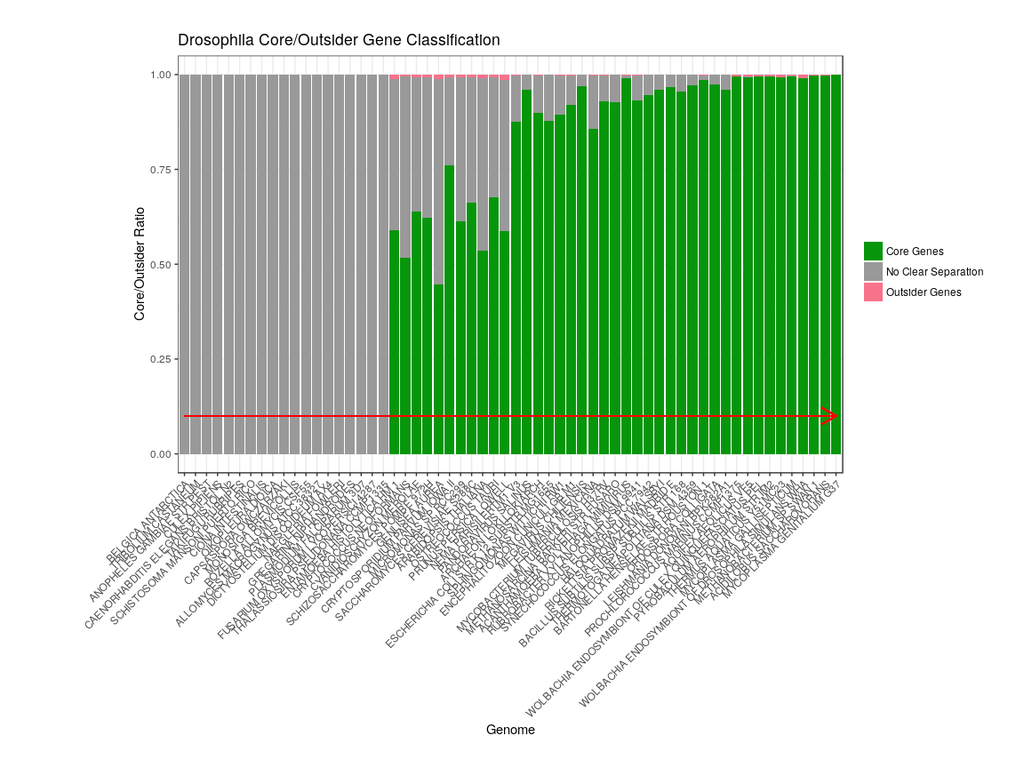

```r
rsq.bar<- core.distribution.data %>% select.genome.data(6) %>% filter.genome.data(6) %>% mutate(id=rownames(.)) %>% melt(id.vars="id") %>% group_by(variable,value) %>%
  summarise(times=n()) %>% do({
    df<- .
    df$times<- rescale(df$times, from = c(0,sum(df$times)),to = c(0,1))
    df
  }) %>% ungroup() %>% mutate(variable=str_replace_all(string=.$variable, pattern ="X", replacement="")) %>%
  merge(x=., y=legend, by.x="variable", by.y="id_genomes") %>%
  merge(x=., y=filter(model.df,query.genome==6|target.genome==6) %>% mutate(variable=sapply(1:nrow(.),function(x){
    if(.$target.genome[x]==6){
      return(.$query.genome[x])
    }else{
      return(.$target.genome[x])
    }
  }))) %>% arrange(rsquared) %>%
  mutate(name=str_trim(toupper(str_replace_all(string=.$name, pattern = "\\.fasta|_|complete_genome|chromosome", replacement=" ")))) %>%
  mutate(name=factor(.$name, levels=unique(.$name))) %>%
  ggplot(data=., mapping=aes(x=name, y=times, group=variable, fill=value, order=value)) +geom_bar(stat="identity") +
  theme_bw() + theme(axis.text.x=element_text(angle=45, hjust=1),plot.margin = unit(c(1, 1, 1, 4), "cm")) +
  xlab("Genome") + ylab("Core/Outsider Ratio") + labs(title="Drosophila Core/Outsider Gene Classification") +
  geom_segment(mapping=aes(x=1, xend=nrow(legend)-1, y=0.1, yend=0.1), arrow=arrow(length=unit(0.5,"cm")),colour="red") +
  scale_fill_manual(values=c("#06960B","#999999","#F7728A"),labels=c("Core Genes","No Clear Separation","Outsider Genes"), guide=guide_legend(title=""))

plot(rsq.bar)
```